# Data Analysis for Researchers 2023, Week 5

2024/01/24

## Part I: EDA with Public Data

## Preview

- Week 5, Jan. 24: EDA4, UN, OECD, readr, readxl, two table verbes, modeling
- Week 6, Jan. 31: EDA5, Round-up, communication, pdf, Word, PowerPoint

### Review

- Responses to Week Four Assignment: [[Link](https://ds-sl.github.io/intro2r/da4r/w4a_response.nb.html)]
  - long table
  - [Option] choropleth map

### Directory and Folder

*Q. Explain the difference between the directory and the folder of PC briefly.*

*A. by Bard.*

Here’s a brief explanation of the differences between directories and folders on a PC:

Directory (Technical Term):

- Fundamental file system structure: It’s the way your computer organizes files and folders in a hierarchical structure.
- Can contain files, subdirectories, and even other directories.
- Abstract concept: It’s not directly visible in graphical user interfaces (GUIs) like Windows Explorer.
- Referred to in command-line interfaces (CLIs) like the Terminal.

Folder (Visual Metaphor):

- Graphical representation of a directory: It’s the icon you see in your file explorer.
- User-friendly way to interact with directories: It allows you to create, move, rename, and delete them.
- May contain files and other folders (subfolders).
- Common term in GUIs: It’s what most people interact with on a daily basis.

Key Points:

- Directories are the underlying structure, while folders are visual representations.
- They’re often used interchangeably in casual conversation.
- Technical discussions often use “directory” for accuracy.
- Both terms refer to a way to organize files on your computer.

### Where are you in R? - Working Directories in Your Project

- The directory of a folder and a file under Files:
  - Shown under Files starting from a house icon.
- Working directory of your project:
  - Run `getwd()` in Console.
- Working directory of your RNotebook:
  - Run `getwd()` in a code chunk.
  - The directory your *`file_name.Rmd`* and *`file_name.nb.html`* is.
- Confirm `data` folder is in the working directory of your RNotebook.

```r
getwd()
```

`[1] "/Users/hsuzuki/Documents/QALL401"`

### R System Command

- Menu: File, Tools: Install Packages, Check for Package Update, Keyboard Shortcut Help, Help: Cheat Sheet, Markdown Quick Reference
- Panes: Source/Visual, Console, Environment tab, History tab, Files, tab, Packages, Help
- Sys.setenv(LANG = “en”) (Sys.setenv(LANG = “ja”))
- data(): loaded data
- ls(): list objects (Environment)
- [Ctrl] + L (^L. Under Edit, Clear Console): clear console
- rm(chosen_indicator_1): remove an object
- rm(list = ls()): remove all

## Importing Data

### Data Location

- Internet link: URL
  - link of the webpage, other information
  - `download.files(url, destifile = "data/name_of_data.XXX", mode = "wb")`
    - `mode = "wb"` for digital files
    - .XXX: extenstions; csv, tsv, xls, xlsx
- `data` folder: downloaded or created data
  - link of the webpage, other information

#### Reproducibility

Keep a record of the data to communicate with others.

### File Types

- Text file: CSV, etc
- Digital file: Excel, etc
- Other: archived compressed file, json, etc.
  - unzip or expand first
  - may contain many files; data, metadata, readme, etc.

### **Importing text data**

- `readr`: a part of `tidyverse`
  - [`read_csv()`](https://readr.tidyverse.org/reference/read_delim.html): comma-separated values (CSV)
  - [`read_tsv()`](https://readr.tidyverse.org/reference/read_delim.html): tab-separated values (TSV)
  - [`read_csv2()`](https://readr.tidyverse.org/reference/read_delim.html): semicolon-separated values with `,` as the decimal mark
  - [`read_delim()`](https://readr.tidyverse.org/reference/read_delim.html): delimited files (CSV and TSV are important special cases)
  - [`read_fwf()`](https://readr.tidyverse.org/reference/read_fwf.html): fixed-width files
  - [`read_table()`](https://readr.tidyverse.org/reference/read_table.html): whitespace-separated files
  - [`read_log()`](https://readr.tidyverse.org/reference/read_log.html): web log files
  - e.g. `df_name <- read_csv("data/datafile.csv")`
- Reference [[readr site](https://readr.tidyverse.org/)] [[CheatSheet](https://rstudio.github.io/cheatsheets/html/data-import.html)]

### **Excel files (xls, xlsx)**

- readxl: a part of tidyverse but you need to load by [`library(readxl)`](https://readxl.tidyverse.org/)
  - `df_name <- read_excel("./data/datafile.xlsx")`
  - `read_xls` and `read_xlsx` are available
  - `sheet = 2`, or `sheet = "name"` See Help.
- Import datasets of RStudio
- Reference
  - [readxl](https://readxl.tidyverse.org/)
  - Data Importing CheatSheet [[Link](https://rstudio.github.io/cheatsheets/html/data-import.html)]

### **Download data file**

- text file (csv, etc.)
  - `download.file(url = "URL", destfile = "./data/file_name.csv")`
  - `df_name <- read_csv(URL)`
    - `write_csv(df_name, "./data/df_name.csv")`
    - `df_name <- read_csv("./data/df_name.csv")`
- digital file (Excel)：`download.file(url = "URL", destfile = "./data/file_name.xlsx", mode = "wb")`

## Two Tables Verbs

**Cheet Sheet: Data transformation with dplyr** See the second page of PDF [[Link](https://rstudio.github.io/cheatsheets/html/data-transformation.html)]

- `left_join(x,y)`: includes all rows in x.
  - `df_wdi_gdp |> left_join(wdicache, by = iso2c)`
  - `df_un_data |> left_join(df_wdi_data, by = c("un_iso2c" = "iso2c")`
  - `df_owid_data |> left_join(df_wdi_data, by = c("region" = "country")`
- `anti_join(x,y, ...)`: return all rows from x without a match in y.
- `semi_join(x,y, ...)`: return all rows from x with a match in y.

### **Need a key to combine with `by` option**

An example

```
library(countrycode)
df_un_data %>% mutate(iso2c_un = countrycode(`Region/Country/Area`, "un", "iso2c"),
  .after = ...2)
```

## Part II: Practicum

## File Links

- Public Data [[Link](https://ds-sl.github.io/intro2r/da4r/public_data.nb.html)], [Rmd]
- Week Five Assignment Template [[Link](https://ds-sl.github.io/intro2r/da4r/w5_assignment_template.nb.html)], [Rmd]

## Week Five Assignment

Choose a data from UN data or OECD data.

- Create an R Notebook of a data analysis containing the following and submit the rendered file (e.g., `w5_g123456.nb.html`) in Moodle.
  1. Create an R Notebook using the R Notebook Template in Moodle and save it as, for example, `w5_g123456.Rmd`.
  2. Edit author with name, ID, and title.
- Contents should include the following:
  - A short abstract
  - Information of data including data name, description and link to reach the data
  - Several charts: a bar graph or a column graph, a histogram, a line graph, a scatter plot
  - Observations or questions for visualizations
- Use left_join, if possible. (a challenge, not required)
- Run each code block and preview to create, for example, `w5_g123456.nb.html`.
  - Or, Run All under Run and Preview to check in your web browser!
  - You can also view your file (e.g. `w5_g123456.nb.html`) by opening it from your web browser.

Submit your R Notebook file (w5_g123456.nb.html) in Moodle (Week Five Assignment).

*Due Sunday 28, January 2024, 11:59 PM*

## World Inequality Database

https://wid.world

### World Inequality Report 2022

- World Inequality Report 2022: https://wir2022.wid.world
- Methodology [[Link](https://wir2022.wid.world/methodology/)]

```r
url_summary <- "https://wir2022.wid.world/www-site/uploads/2022/03/WIR2022TablesFigures-Summary.xlsx"
download.file(url = url_summary, destfile = "data/WIR2022s.xlsx", mode = "wb")
```

```r
library(readxl) # readxl is a part of tidyverse but not a core package
```

```r
excel_sheets("data/WIR2022s.xlsx")
```

```
##  [1] "Index"     "F1"        "F2"        "F3"        "F4"        "F5."
##  [7] "F6"        "F7"        "F8"        "F9"        "F10"       "F11"
## [13] "F12"       "F13"       "F14"       "F15"       "T1"        "data-F1"
## [19] "data-F2"   "data-F3"   "data-F4"   "data-F5"   "data-F6"   "data-F7"
## [25] "data-F8"   "data-F9"   "data-F10"  "data-F11"  "data-F12"  "data-F13."
## [31] "data-F14." "data-F15"
```

```r
df_wir_f2 <- read_excel("data/WIR2022s.xlsx",
    sheet = "data-F2")
df_wir_f2
```

```
## # A tibble: 8 × 5
##    year iso                     `Bottom 50%` `Middle 40%` `Top 10%`
##   <dbl> <chr>                          <dbl>        <dbl>     <dbl>
## 1  2021 Europe                        0.189         0.453     0.358
## 2  2021 East Asia                     0.139         0.427     0.434
## 3  2021 North America                 0.132         0.411     0.457
## 4  2021 Russia & Central Asia         0.147         0.386     0.467
## 5  2021 South & South East Asia       0.123         0.328     0.548
## 6  2021 Latin America                 0.102         0.344     0.554
## 7  2021 Sub-Saharan Africa            0.0892        0.354     0.557
## 8  2021 MENA                          0.09          0.329     0.581
```

Created a new Excel book with only one sheet, and save it as a CSV UTF-8.

```r
df_wir_f2_2 <- read_csv("data/wir-f2.csv")
df_wir_f2_2
```

```
## # A tibble: 8 × 5
##    year iso                     `Bottom 50%` `Middle 40%` `Top 10%`
##   <dbl> <chr>                   <chr>        <chr>        <chr>
## 1  2021 Europe                  19%          45%          36%
## 2  2021 East Asia               14%          43%          43%
## 3  2021 North America           13%          41%          46%
## 4  2021 Russia & Central Asia   15%          39%          47%
## 5  2021 South & South East Asia 12%          33%          55%
## 6  2021 Latin America           10%          34%          55%
## 7  2021 Sub-Saharan Africa      9%           35%          56%
## 8  2021 MENA                    9%           33%          58%
```

```r
df_wir_f2_2 |> identical(df_wir_f2)
```

```
## [1] FALSE
```

```r
df_wir_f2_3 <- read_delim(clipboard())
df_wir_f2_3
```

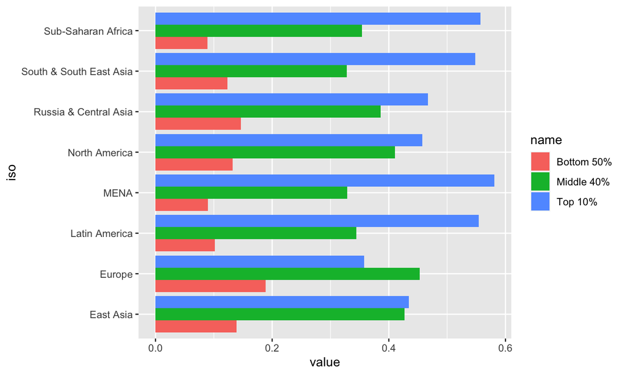

```r
df_wir_f2 |> pivot_longer(3:5) |>
  ggplot(aes(iso, value, fill = name)) + geom_col(position = "dodge") + coord_flip()
```

See: https://ds-sl.github.io/data-analysis/wir2022.nb.html

### To share data with someone else.

```r
df_wir_dput <- dput(df_wir_f2)
```

```
## structure(list(year = c(2021, 2021, 2021, 2021, 2021, 2021, 2021,
## 2021), iso = c("Europe", "East Asia", "North America", "Russia & Central Asia",
## "South & South East Asia", "Latin America", "Sub-Saharan Africa",
## "MENA"), `Bottom 50%` = c(0.1891, 0.1391, 0.1322, 0.1466, 0.1233,
## 0.1016, 0.0892, 0.09), `Middle 40%` = c(0.4531, 0.4268, 0.4105,
## 0.3863, 0.3283, 0.3445, 0.3537, 0.3288), `Top 10%` = c(0.3578,
## 0.4341, 0.4573, 0.4671, 0.5484, 0.5539, 0.5571, 0.5812)), class = c("tbl_df",
## "tbl", "data.frame"), row.names = c(NA, -8L))
```

```r
df_wir_dput
```

```
## # A tibble: 8 × 5
##    year iso                     `Bottom 50%` `Middle 40%` `Top 10%`
##   <dbl> <chr>                          <dbl>        <dbl>     <dbl>
## 1  2021 Europe                        0.189         0.453     0.358
## 2  2021 East Asia                     0.139         0.427     0.434
## 3  2021 North America                 0.132         0.411     0.457
## 4  2021 Russia & Central Asia         0.147         0.386     0.467
## 5  2021 South & South East Asia       0.123         0.328     0.548
## 6  2021 Latin America                 0.102         0.344     0.554
## 7  2021 Sub-Saharan Africa            0.0892        0.354     0.557
## 8  2021 MENA                          0.09          0.329     0.581
```

```r
df_wir_f2_3 <- df_wir_dput
df_wir_f2_3 |> identical(df_wir_f2)
```

```
## [1] TRUE
```

## UNdata - a world of information

https://data.un.org/

Popular statistical tables

Explorer - datamarts: http://data.un.org/Explorer.aspx

- Datasets, Sources, Topics

### Popular statistical tables

Copy the link of International Migrants and Refugees

```r
un_migrants_url <- "https://data.un.org/_Docs/SYB/CSV/SYB66_327_202310_International%20Migrants%20and%20Refugees.csv"
download.file(un_migrants_url, destfile = "data/migrants.csv")
```

```r
df_un_migrants <- read_csv("data/migrants.csv")
```

```
## ──────────────────────────────────────────────────────── Delimiter: "," chr
## (7): T04, International migrants and refugees, ...3, ...4, ...5, ...6, ...7
```

```r
df_un_migrants
```

```
## # A tibble: 7,239 × 7
##    T04                 International migrants an…¹ ...3  ...4  ...5  ...6  ...7
##    <chr>               <chr>                       <chr> <chr> <chr> <chr> <chr>
##  1 Region/Country/Area <NA>                        Year  Seri… Value Foot… Sour…
##  2 1                   Total, all countries or ar… 2005  Inte… 191,… <NA>  Unit…
##  3 1                   Total, all countries or ar… 2005  Inte… 2.9   <NA>  Unit…
##  4 1                   Total, all countries or ar… 2005  Inte… 3.0   <NA>  Unit…
##  5 1                   Total, all countries or ar… 2005  Inte… 2.9   <NA>  Unit…
##  6 1                   Total, all countries or ar… 2010  Inte… 220,… <NA>  Unit…
##  7 1                   Total, all countries or ar… 2010  Inte… 3.2   <NA>  Unit…
##  8 1                   Total, all countries or ar… 2010  Inte… 3.2   <NA>  Unit…
##  9 1                   Total, all countries or ar… 2010  Inte… 3.1   <NA>  Unit…
## 10 1                   Total, all countries or ar… 2015  Inte… 247,… <NA>  Unit…
## # ℹ 7,229 more rows
## # ℹ abbreviated name: ¹`International migrants and refugees`
```

```r
df_un_migrants <- read_csv("data/migrants.csv", skip=1)
```

```
## ──────────────────────────────────────────────────────── Delimiter: "," chr
## (4): ...2, Series, Footnotes, Source dbl (2): Region/Country/Area, Year num
## (1): Value
```

```r
df_un_migrants
```

```
## # A tibble: 7,238 × 7
##    `Region/Country/Area` ...2                Year Series  Value Footnotes Source
##                    <dbl> <chr>              <dbl> <chr>   <dbl> <chr>     <chr>
##  1                     1 Total, all countr…  2005 Inter… 1.91e8 <NA>      Unite…
##  2                     1 Total, all countr…  2005 Inter… 2.9 e0 <NA>      Unite…
##  3                     1 Total, all countr…  2005 Inter… 3   e0 <NA>      Unite…
##  4                     1 Total, all countr…  2005 Inter… 2.9 e0 <NA>      Unite…
##  5                     1 Total, all countr…  2010 Inter… 2.21e8 <NA>      Unite…
##  6                     1 Total, all countr…  2010 Inter… 3.2 e0 <NA>      Unite…
##  7                     1 Total, all countr…  2010 Inter… 3.2 e0 <NA>      Unite…
##  8                     1 Total, all countr…  2010 Inter… 3.1 e0 <NA>      Unite…
##  9                     1 Total, all countr…  2015 Inter… 2.48e8 <NA>      Unite…
## 10                     1 Total, all countr…  2015 Inter… 3.4 e0 <NA>      Unite…
## # ℹ 7,228 more rows
```

### Explorer - datamarts

Environment Statistics Database>Water>Internal flow [[Link](http://data.un.org/Data.aspx?d=ENV&f=variableID:5&c=2,3,4,5&s=countryName:asc,yr:desc&v=1)]

```r
df_un_water <- read_csv("data/UNdata_Export_20240124_010609671.csv")
df_un_water
```

```
## # A tibble: 1,604 × 7
##    `Table ID` `Country or Area Code` `Country or Area`  Year  Value
##         <dbl> <chr>                  <chr>             <dbl>  <dbl>
##  1          5 8                      Albania            2017 18368
##  2          5 8                      Albania            2016 21846
##  3          5 8                      Albania            2015 19300
##  4          5 8                      Albania            2014 20445
##  5          5 8                      Albania            2013 17451
##  6          5 20                     Andorra            2019   367.
##  7          5 20                     Andorra            2018   339
##  8          5 20                     Andorra            2017   284.
##  9          5 20                     Andorra            2016   301.
## 10          5 20                     Andorra            2015   251
## # ℹ 1,594 more rows
## # ℹ 2 more variables: `Value Footnotes` <dbl>, Unit <chr>
```

```r
url_un_migrants <- "https://data.un.org/_Docs/SYB/CSV/SYB66_327_202310_International%20Migrants%20and%20Refugees.csv"
```

```r
df_un_migrants <- read_csv(url_un_migrants, skip = 1)
```

```
## ──────────────────────────────────────────────────────── Delimiter: "," chr
## (4): ...2, Series, Footnotes, Source dbl (2): Region/Country/Area, Year num
## (1): Value
```

```r
df_un_migrants
```

```
## # A tibble: 7,238 × 7
##    `Region/Country/Area` ...2                Year Series  Value Footnotes Source
##                    <dbl> <chr>              <dbl> <chr>   <dbl> <chr>     <chr>
##  1                     1 Total, all countr…  2005 Inter… 1.91e8 <NA>      Unite…
##  2                     1 Total, all countr…  2005 Inter… 2.9 e0 <NA>      Unite…
##  3                     1 Total, all countr…  2005 Inter… 3   e0 <NA>      Unite…
##  4                     1 Total, all countr…  2005 Inter… 2.9 e0 <NA>      Unite…
##  5                     1 Total, all countr…  2010 Inter… 2.21e8 <NA>      Unite…
##  6                     1 Total, all countr…  2010 Inter… 3.2 e0 <NA>      Unite…
##  7                     1 Total, all countr…  2010 Inter… 3.2 e0 <NA>      Unite…
##  8                     1 Total, all countr…  2010 Inter… 3.1 e0 <NA>      Unite…
##  9                     1 Total, all countr…  2015 Inter… 2.48e8 <NA>      Unite…
## 10                     1 Total, all countr…  2015 Inter… 3.4 e0 <NA>      Unite…
## # ℹ 7,228 more rows
```

```r
str(df_un_migrants)
```

```
## spc_tbl_ [7,238 × 7] (S3: spec_tbl_df/tbl_df/tbl/data.frame)
##  $ Region/Country/Area: num [1:7238] 1 1 1 1 1 1 1 1 1 1 ...
##  $ ...2               : chr [1:7238] "Total, all countries or areas" "Total, all countries or areas" "Total, all countries or areas" "Total, all countries or areas" ...
##  $ Year               : num [1:7238] 2005 2005 2005 2005 2010 ...
##  $ Series             : chr [1:7238] "International migrant stock: Both sexes (number)" "International migrant stock: Both sexes (% total population)" "International migrant stock: Male (% total Population)" "International migrant stock: Female (% total Population)" ...
##  $ Value              : num [1:7238] 1.91e+08 2.90 3.00 2.90 2.21e+08 ...
##  $ Footnotes          : chr [1:7238] NA NA NA NA ...
##  $ Source             : chr [1:7238] "United Nations Population Division, New York, International migrant stock: The 2020 Revision, last accessed January 2022." "United Nations Population Division, New York, International migrant stock: The 2020 Revision, last accessed January 2022." "United Nati…
##  - attr(*, "spec")=
##   .. cols(
##   ..   `Region/Country/Area` = col_double(),
##   ..   ...2 = col_character(),
##   ..   Year = col_double(),
##   ..   Series = col_character(),
##   ..   Value = col_number(),
##   ..   Footnotes = col_character(),
##   ..   Source = col_character()
##   .. )
##  - attr(*, "problems")=<externalptr>
```

```r
df_un_migrants |> summary()
```

```
##  Region/Country/Area     ...2                Year         Series
##  Min.   :  1.0       Length:7238        Min.   :2005   Length:7238
##  1st Qu.:178.0       Class :character   1st Qu.:2010   Class :character
##  Median :404.0       Mode  :character   Median :2015   Mode  :character
##  Mean   :407.1                          Mean   :2014
##  3rd Qu.:630.0                          3rd Qu.:2020
##  Max.   :894.0                          Max.   :2022
##      Value            Footnotes            Source
##  Min.   :        0   Length:7238        Length:7238
##  1st Qu.:        5   Class :character   Class :character
##  Median :      154   Mode  :character   Mode  :character
##  Mean   :   731059
##  3rd Qu.:    31096
##  Max.   :280598105
```

```r
df_un_migrants |> select(Year,Series) |> lapply(unique)
```

```
## $Year
##  [1] 2005 2010 2015 2020 2022 2019 2018 2016 2021 2017
##
## $Series
## [1] "International migrant stock: Both sexes (number)"
## [2] "International migrant stock: Both sexes (% total population)"
## [3] "International migrant stock: Male (% total Population)"
## [4] "International migrant stock: Female (% total Population)"
## [5] "Total refugees and people in refugee-like situations (number)"
## [6] "Asylum seekers, including pending cases (number)"
## [7] "Other of concern to UNHCR (number)"
## [8] "Total population of concern to UNHCR (number)"
```

```r
df_un_migrants |> distinct(`Region/Country/Area`, ...2)
```

[output not shown]

```r
library(countrycode)
df_un_migrants %>% mutate(iso2c_un = countrycode(`Region/Country/Area`, "un", "iso2c"), .after = ...2)
```

```
## # A tibble: 7,238 × 8
##    `Region/Country/Area` ...2      iso2c_un  Year Series  Value Footnotes Source
##                    <dbl> <chr>     <chr>    <dbl> <chr>   <dbl> <chr>     <chr>
##  1                     1 Total, a… <NA>      2005 Inter… 1.91e8 <NA>      Unite…
##  2                     1 Total, a… <NA>      2005 Inter… 2.9 e0 <NA>      Unite…
##  3                     1 Total, a… <NA>      2005 Inter… 3   e0 <NA>      Unite…
##  4                     1 Total, a… <NA>      2005 Inter… 2.9 e0 <NA>      Unite…
##  5                     1 Total, a… <NA>      2010 Inter… 2.21e8 <NA>      Unite…
##  6                     1 Total, a… <NA>      2010 Inter… 3.2 e0 <NA>      Unite…
##  7                     1 Total, a… <NA>      2010 Inter… 3.2 e0 <NA>      Unite…
##  8                     1 Total, a… <NA>      2010 Inter… 3.1 e0 <NA>      Unite…
##  9                     1 Total, a… <NA>      2015 Inter… 2.48e8 <NA>      Unite…
## 10                     1 Total, a… <NA>      2015 Inter… 3.4 e0 <NA>      Unite…
## # ℹ 7,228 more rows
```

```r
df_un_migrants |> mutate(iso2c_un = countrycode(`Region/Country/Area`, "un", "iso2c"), .after = ...2) |> filter(is.na(iso2c_un)) |> distinct(...2)
```

```
## # A tibble: 32 × 1
##    ...2
##    <chr>
##  1 Total, all countries or areas
##  2 Africa
##  3 Northern Africa
##  4 Sub-Saharan Africa
##  5 Eastern Africa
##  6 Middle Africa
##  7 Southern Africa
##  8 Western Africa
##  9 Northern America
## 10 Latin America & the Caribbean
## # ℹ 22 more rows
```

```r
wdicache <- read_rds("data/wdicache.rds")
wdi_country_extra <- wdicache$country |> select(iso2c, region, income, lending)
```

```r
df_un_migrants_ext <- df_un_migrants %>%
  mutate(iso2c_un = countrycode(`Region/Country/Area`, "un", "iso2c"), .after = ...2) |>
  drop_na(iso2c_un) |>
  select(Country = ...2, ISO2C = iso2c_un, Year, Series, Value, Footnotes) |>
  left_join(wdi_country_extra, by = c("ISO2C" = "iso2c"))
df_un_migrants_ext
```

```
## # A tibble: 6,673 × 9
##    Country     ISO2C  Year Series          Value Footnotes region income lending
##    <chr>       <chr> <dbl> <chr>           <dbl> <chr>     <chr>  <chr>  <chr>
##  1 Afghanistan AF     2005 Internationa… 8.73e+4 Includin… South… Low i… IDA
##  2 Afghanistan AF     2005 Internationa… 3   e-1 Includin… South… Low i… IDA
##  3 Afghanistan AF     2005 Internationa… 4   e-1 Includin… South… Low i… IDA
##  4 Afghanistan AF     2005 Internationa… 3   e-1 Includin… South… Low i… IDA
##  5 Afghanistan AF     2005 Total refuge… 3.2 e+1 <NA>      South… Low i… IDA
##  6 Afghanistan AF     2005 Asylum seeke… 1.4 e+1 <NA>      South… Low i… IDA
##  7 Afghanistan AF     2005 Other of con… 1.60e+5 <NA>      South… Low i… IDA
##  8 Afghanistan AF     2005 Total popula… 1.60e+5 <NA>      South… Low i… IDA
##  9 Afghanistan AF     2010 Internationa… 1.02e+5 Includin… South… Low i… IDA
## 10 Afghanistan AF     2010 Internationa… 4   e-1 Includin… South… Low i… IDA
## # ℹ 6,663 more rows
```

```r
df_un_migrants_ext$Series |> unique()
```

```
## [1] "International migrant stock: Both sexes (number)"
## [2] "International migrant stock: Both sexes (% total population)"
## [3] "International migrant stock: Male (% total Population)"
## [4] "International migrant stock: Female (% total Population)"
## [5] "Total refugees and people in refugee-like situations (number)"
## [6] "Asylum seekers, including pending cases (number)"
## [7] "Other of concern to UNHCR (number)"
## [8] "Total population of concern to UNHCR (number)"
```

```r
df_un_migrants_ext_rev <- df_un_migrants_ext |> mutate(Ser = case_when(
  Series == "International migrant stock: Both sexes (number)" ~ "migrant",
  Series == "International migrant stock: Both sexes (% total population)" ~ "migrant_percent",
  Series == "International migrant stock: Male (% total Population)" ~ "migrant_male",
  Series == "International migrant stock: Female (% total Population)" ~ "migrant_female",
  Series == "Total refugees and people in refugee-like situations (number)" ~ "refugee",
  Series == "Asylum seekers, including pending cases (number)" ~ "asylum",
  Series == "Other of concern to UNHCR (number)"  ~ "other",
  Series == "Total population of concern to UNHCR (number)" ~ "concern",
  TRUE ~ Series), .before = Series)
```

```r
df_un_migrants_ext_rev
```

```
## # A tibble: 6,673 × 10
##    Country     ISO2C  Year Ser    Series   Value Footnotes region income lending
##    <chr>       <chr> <dbl> <chr>  <chr>    <dbl> <chr>     <chr>  <chr>  <chr>
##  1 Afghanistan AF     2005 migra… Inter… 8.73e+4 Includin… South… Low i… IDA
##  2 Afghanistan AF     2005 migra… Inter… 3   e-1 Includin… South… Low i… IDA
##  3 Afghanistan AF     2005 migra… Inter… 4   e-1 Includin… South… Low i… IDA
##  4 Afghanistan AF     2005 migra… Inter… 3   e-1 Includin… South… Low i… IDA
##  5 Afghanistan AF     2005 refug… Total… 3.2 e+1 <NA>      South… Low i… IDA
##  6 Afghanistan AF     2005 asylum Asylu… 1.4 e+1 <NA>      South… Low i… IDA
##  7 Afghanistan AF     2005 other  Other… 1.60e+5 <NA>      South… Low i… IDA
##  8 Afghanistan AF     2005 conce… Total… 1.60e+5 <NA>      South… Low i… IDA
##  9 Afghanistan AF     2010 migra… Inter… 1.02e+5 Includin… South… Low i… IDA
## 10 Afghanistan AF     2010 migra… Inter… 4   e-1 Includin… South… Low i… IDA
## # ℹ 6,663 more rows
```

```r
dput(df_un_migrants_ext_rev)
```

## OECD data

https://data.oecd.org/

Database Access: https://data-explorer.oecd.org/

### Expenditure on educational institutions per full-time equivalent student

[Link]

Table in Excel, Filtered data in tableau text (CSV), Unfiltered data in tableau text (CSV) 136.4MB

```r
temp <- read_csv("../../../bigdata/OECD.EDU.IMEP,DSD_EAG_UOE_FIN@DF_UOE_INDIC_FIN_PERSTUD,1.0+all.csv")
```

```
## ──────────────────────────────────────────────────────── Delimiter: "," chr
## (12): STRUCTURE, STRUCTURE_ID, ACTION, MEASURE, REF_AREA, EDUCATION_LEV,... dbl
## (4): TIME_PERIOD, OBS_VALUE, UNIT_MULT, DECIMALS lgl (16): STRUCTURE_NAME,
## ...6, ...8, ...10, ...12, ...14, ...16, ...18, ......
```

```r
temp
```

```
## # A tibble: 809,280 × 32
##    STRUCTURE STRUCTURE_ID     STRUCTURE_NAME ACTION MEASURE ...6  REF_AREA ...8
##    <chr>     <chr>            <lgl>          <chr>  <chr>   <lgl> <chr>    <lgl>
##  1 DATAFLOW  OECD.EDU.IMEP:D… NA             I      FIN_PE… NA    CHE      NA
##  2 DATAFLOW  OECD.EDU.IMEP:D… NA             I      FIN_PE… NA    CHE      NA
##  3 DATAFLOW  OECD.EDU.IMEP:D… NA             I      FIN_PE… NA    CHE      NA
##  4 DATAFLOW  OECD.EDU.IMEP:D… NA             I      FIN_PE… NA    CHE      NA
##  5 DATAFLOW  OECD.EDU.IMEP:D… NA             I      FIN_PE… NA    CHE      NA
##  6 DATAFLOW  OECD.EDU.IMEP:D… NA             I      FIN_PE… NA    CHE      NA
##  7 DATAFLOW  OECD.EDU.IMEP:D… NA             I      FIN_PE… NA    CHE      NA
##  8 DATAFLOW  OECD.EDU.IMEP:D… NA             I      FIN_PE… NA    CHE      NA
##  9 DATAFLOW  OECD.EDU.IMEP:D… NA             I      FIN_PE… NA    CHE      NA
## 10 DATAFLOW  OECD.EDU.IMEP:D… NA             I      FIN_PE… NA    CHE      NA
## # ℹ 809,270 more rows
## # ℹ 24 more variables: EDUCATION_LEV <chr>, ...10 <lgl>, EXP_SOURCE <chr>,
## #   ...12 <lgl>, EXP_DESTINATION <chr>, ...14 <lgl>, EXPENDITURE_TYPE <chr>,
## #   ...16 <lgl>, PRICE_BASE <chr>, ...18 <lgl>, UNIT_MEASURE <chr>,
## #   ...20 <lgl>, TIME_PERIOD <dbl>, ...22 <lgl>, OBS_VALUE <dbl>, ...24 <lgl>,
## #   OBS_STATUS <chr>, ...26 <lgl>, UNIT_MULT <dbl>, ...28 <lgl>,
## #   DECIMALS <dbl>, ...30 <lgl>, BASE_PER <lgl>, ...32 <lgl>
```

```r
library(readxl)
df_oecd_ed <- read_excel("data/OECD.EDU.IMEP,DSD_EAG_UOE_FIN@DF_UOE_INDIC_FIN_PERSTUD,1.0,filtered,2024-01-24 10-22-31.xlsx")
df_oecd_ed
```

```
## # A tibble: 113 × 13
##    Expenditure on educat…¹ ...2  ...3  ...4  ...5  ...6  ...7  ...8  ...9  ...10
##    <chr>                   <chr> <chr> <chr> <chr> <chr> <chr> <chr> <chr> <chr>
##  1 Measure: Expenditure p… <NA>  <NA>  <NA>  <NA>  <NA>   <NA>  <NA> <NA>  <NA>
##  2 Destination of expendi… <NA>  <NA>  <NA>  <NA>  <NA>   <NA>  <NA> <NA>  <NA>
##  3 Type of expenditure: E… <NA>  <NA>  <NA>  <NA>  <NA>   <NA>  <NA> <NA>  <NA>
##  4 Time period: 2020       <NA>  <NA>  <NA>  <NA>  <NA>   <NA>  <NA> <NA>  <NA>
##  5 <NA>                    <NA>  <NA>  <NA>  <NA>  <NA>   <NA>  <NA> <NA>  <NA>
##  6 Education level         Educ… Prim… Prim… Lowe… Uppe… "· \… "· \… Post… Tert…
##  7 Reference area          <NA>  <NA>  <NA>  <NA>  <NA>   <NA>  <NA> <NA>  <NA>
##  8 Combined unit of measu… <NA>  <NA>  <NA>  <NA>  <NA>   <NA>  <NA> <NA>  <NA>
##  9 Australia               <NA>  1562… 1267… 1571… 1494… "160… "119… 1016… 2220…
## 10 Austria                 <NA>  1774… 1402… 1730… 1769… "151… "194… 4626… 2175…
## # ℹ 103 more rows
## # ℹ abbreviated name:
## #   ¹`Expenditure on educational institutions per full-time equivalent student`
## # ℹ 3 more variables: ...11 <chr>, ...12 <chr>, ...13 <chr>
```

```r
df_oecd_ed <- read_excel("data/OECD.EDU.IMEP,DSD_EAG_UOE_FIN@DF_UOE_INDIC_FIN_PERSTUD,1.0,filtered,2024-01-24 10-22-31.xlsx", skip = 6) |> drop_na(3)
df_oecd_ed
```

```
## # A tibble: 102 × 13
##    `Education level...1` `Education level...2` `Primary to tertiary education`
##    <chr>                 <lgl>                 <chr>
##  1 Australia             NA                    15620.15
##  2 Austria               NA                    17743.801
##  3 Belgium               NA                    16428.811
##  4 Canada                NA                    15442.98
##  5 Chile                 NA                    7183.8838
##  6 Colombia              NA                    4481.4321
##  7 Costa Rica            NA                    O ..
##  8 Czechia               NA                    11845.81
##  9 Denmark               NA                    16311.53
## 10 Estonia               NA                    11087.88
## # ℹ 92 more rows
## # ℹ 10 more variables: `Primary education` <chr>,
## #   `Lower secondary education` <chr>, `Upper secondary education` <chr>,
## #   `· \nUpper secondary general education` <chr>,
## #   `· \nUpper secondary vocational education` <chr>,
## #   `Post-secondary non-tertiary education` <chr>, `Tertiary education` <chr>,
## #   `· \nShort-cycle tertiary education` <chr>, …
```

## Modeling

- searching models: few numbers
- linear regression

```r
cars
```

```
##    speed dist
## 1      4    2
## 2      4   10
## 3      7    4
## 4      7   22
## 5      8   16
## 6      9   10
## 7     10   18
## 8     10   26
## 9     10   34
## 10    11   17
## 11    11   28
## 12    12   14
## 13    12   20
## 14    12   24
```

[output cut: 36 more lines]

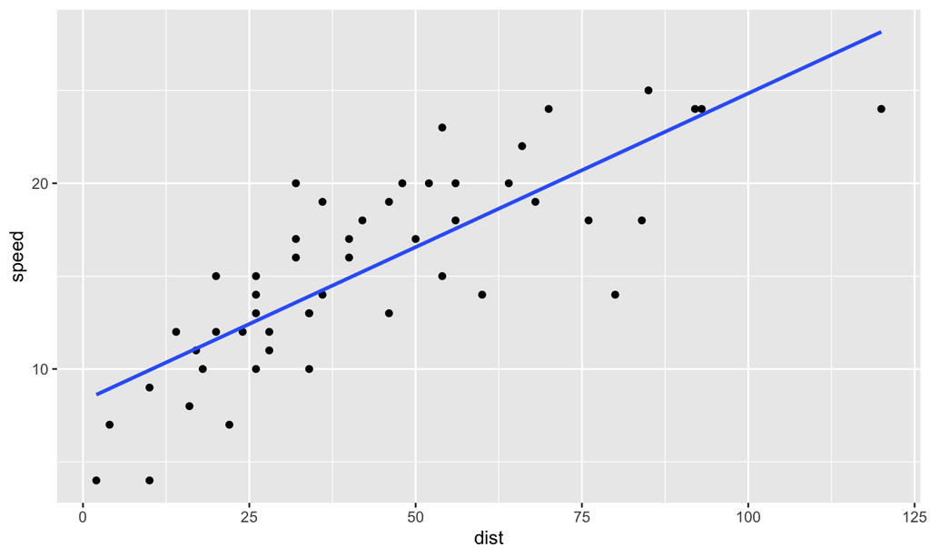

```r
cars |> ggplot(aes(dist, speed)) + geom_point() +
  geom_smooth(formula = 'y ~ x', method = "lm", se=FALSE)
```

```r
cars |> lm(dist ~ speed, data = _) |> summary()
```

```
##
## Call:
## lm(formula = dist ~ speed, data = cars)
##
## Residuals:
##     Min      1Q  Median      3Q     Max
## -29.069  -9.525  -2.272   9.215  43.201
##
## Coefficients:
##             Estimate Std. Error t value Pr(>|t|)
## (Intercept) -17.5791     6.7584  -2.601   0.0123 *
## speed         3.9324     0.4155   9.464 1.49e-12 ***
## ---
## Signif. codes:  0 '***' 0.001 '**' 0.01 '*' 0.05 '.' 0.1 ' ' 1
##
## Residual standard error: 15.38 on 48 degrees of freedom
## Multiple R-squared:  0.6511, Adjusted R-squared:  0.6438
## F-statistic: 89.57 on 1 and 48 DF,  p-value: 1.49e-12
```

## References

- Data Analysis for Researchers. [[Link](https://icu-hsuzuki.github.io/da4r/)]
- H. Wickham. *R for Data Science (2e)*. [[Link](https://r4ds.hadley.nz)]・[[O’REILLY](https://www.oreilly.com/library/view/r-for-data/9781492097396/)].
  - Data transformation [[Link](https://r4ds.hadley.nz/data-transform)]
  - Data tidying [[Link](https://r4ds.hadley.nz/data-tidy)]
  - Data import [[Link](https://r4ds.hadley.nz/data-import)]
  - Import [[Link](https://r4ds.hadley.nz/import)]
- Posit Recipes（New edition of Posit Primers）: interactive exercises [[Link](https://posit.cloud/learn/recipes)]
- Cheat Sheet. [[Site Link](https://rstudio.github.io/cheatsheets/)]
  - Data import with the tidyverse [[Link](https://rstudio.github.io/cheatsheets/html/data-import.html)]
  - Data transformation with dplyr [[Link](https://rstudio.github.io/cheatsheets/html/data-transformation.html)]
- dplyr: A Grammar of Data Manipulation [[Link](https://CRAN.R-project.org/package=dplyr)]
  - Two-table verbs [[Link](https://cran.r-project.org/web/packages/dplyr/vignettes/two-table.html)]
- Model Summary
  - r-statistics.co by Selva Prabhakaran:
    - http://r-statistics.co/Linear-Regression.html
  - Meaning Behind Each Section of Summary()
    - https://www.learnbymarketing.com/tutorials/explaining-the-lm-summary-in-r/
- swirl: `install.packages("swirl")` `libray(swirl)`, and `swirl()` after `rm(list=ls())`